# Anthropometric Dataset Egyptian Skulls Dataset

Instructor: Jill E. Thomley (thomleyje@appstate.edu)

Updated: Friday, September 21, 2018 @ 01:22:32 PM

anthropometric.csv

egyptianskulls.csv

### Description

Anthropometry is the measurement and study of the physical proportions and functional capabilities of the human body. The name is derived from the Greek word anthros, meaning “man,” and metron, meaning “measure”. Today human measurements are used for a variety of design, health, and [safety](https://www.cdc.gov/niosh/topics/anthropometry/default.html) purposes, including [crash test dummies](http://www.humaneticsatd.com/crash-test-dummies/). The contemporary field of ergonomics (also known as human factors) explicitly considers anthropometric concepts and principles in the design of products, processes, and systems intended for use by people (e.g., clothing, furniture, medical devices, hand tools, keyboards, vehicles). Crime scene investigators, pathologists, historians, and forensic anthropologists also make extensive use of anthropometric measurements. Craniometry refers to measurements of the cranium (skull).

Belgian scholar [Adolphe Quetelet](http://www-groups.dcs.st-and.ac.uk/history/Biographies/Quetelet.html) (1796-1874) was a pioneer in anthopometry. Among his many pursuits, which included investigations in the disciplines later known as sociology and criminology, he was interested in the quantification of what he referred to as l’homme moyen (the average man). His measurements helped to demonstrate the natural distribution and variability of various aspects of the human body, like height and weight, both of which he believed followed a bell-shaped curve (i.e., normal distribution). The measure we now call Body Mass Index (BMI) was developed by Quetelet sometime between 1830 and 1850.

Although he was among the first to approach anthropometrics in a systematic manner, Quetelet was certainly not the first person to theorize about human measurements. Roman architect and engineer Vitruvius (approximately 80 BC-15 BC) wrote [Ten Books on Architecture](http://www.gutenberg.org/ebooks/20239) (circa 20 BC), which is one of the most important sources of information on Roman building methods. It also included his thoughts about the proportionality of the human body and how these geometric features relate to divinity and the ideal design of man-made structures. He suggested (among other things) that people are squares: “the length of the outspread arms is equal to the height of a man”. Other statements include “the length of the hand is one-tenth of the height of a man” and “from below the foot to below the knee is a quarter of the height of a man.” Some of these ideas were illustrated by Leonardo da Vinci (1452-1590) in his famous pen-and-ink drawing “[The Vitruvian Man](https://leonardodavinci.stanford.edu/submissions/clabaugh/history/leonardo.html)” (~1490 AD). In 2008, Time magazine published a picture of Olympic medalist Michael helps in a Vitruvian Man pose to illustrate what some call his “[freakish physique](http://gawker.com/5038018/michael-phelps-freakish-physique-explained%22), a term that has also applied been to surfer [Owen Wright](https://stabmag.com/style/the-anatomy-of-owen-wright/).

### Variables

Anthropometric

- gender: self-identified gender
- ideal: self-chosen ideal height in inches
- height: measured heigth in inches
- armspan: measured armspan in inches
- forearm: measured forearm length in inches (elbow crease to middle fingertip)
- hand: measured hand length in inches (wrist crease to tip of middle finger)
- leg: measured lower leg length in inches (crease at back of knee to floor)
- foot: foot length in inches (back of heel to tip of longest toe)
- semester: semester the measurement was made

```
## Observations: 547
## Variables: 9
## $ gender   <fct> female, female, female, female, female, female, femal...
## $ ideal    <dbl> 64, 64, 65, 63, 68, 64, NA, 65, 66, 63, 62, 60, 65, 6...
## $ height   <dbl> 59.75, 59.75, 60.00, 60.00, 60.00, 60.00, 60.50, 60.5...
## $ armspan  <dbl> 58.5, 58.5, 61.0, 58.0, 62.0, 60.0, 60.0, 61.5, 63.0,...
## $ forearm  <dbl> 15.00, 15.00, 16.00, 15.00, 15.00, 15.00, 15.50, 15.0...
## $ hand     <dbl> 6.50, 6.50, 7.00, 6.25, 6.00, 6.00, 5.50, 7.00, 7.00,...
## $ leg      <dbl> 16.00, 16.00, 16.00, 16.25, 18.00, 16.00, 17.75, 16.5...
## $ foot     <dbl> 8.50, 8.50, 8.50, 9.50, 9.00, 8.00, 8.50, 8.50, 9.50,...
## $ semester <fct> F15, F15, F13, F15, S13, Sum13, S14, Sum14, F15, S13,...
```

Egyptian Skulls

- maxbreadth: see image below (in mm)
- basibregmatic: see image below (in mm)
- basialveolar: see image below (in mm)
- nasalht: see image below (in mm)
- time1: years before or after 0 C.E.
- time2: time as categories
  - early predynastic period (circa 4000 BCE)
  - late predynastic period (circa 3300 BCE)
  - 12th and 13th dynasties (circa 1850 BCE)
  - Ptolemiac period (circa 200 BCE)
  - Roman period (circa 150 CE)

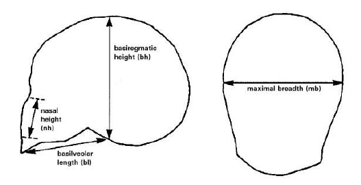

```
## Observations: 150
## Variables: 6
## $ maxbreadth    <int> 131, 125, 131, 119, 136, 138, 139, 125, 131, 134...
## $ basibregmatic <int> 138, 131, 132, 132, 143, 137, 130, 136, 134, 134...
## $ basialveolar  <int> 89, 92, 99, 96, 100, 89, 108, 93, 102, 99, 95, 9...
## $ nasalht       <int> 49, 48, 50, 44, 54, 56, 48, 48, 51, 51, 50, 53, ...
## $ time1         <int> -4000, -4000, -4000, -4000, -4000, -4000, -4000,...
## $ time2         <fct> BCE.4000, BCE.4000, BCE.4000, BCE.4000, BCE.4000...
```

### References

Thomson, Arthur and Randall-MacIver, David. (1905). [Ancient Races of the Thebaid](https://books.google.com/books/about/The_Ancient_Races_of_the_Thebaid.html?id=7eQ-AAAAYAAJ). Oxford: Oxford University Press.

Anthropometric data were collected from students in Dr. Thomley’s STT1810 and STT3850 courses.